# Problem Set 4

Patrick Altmeyer, Buelent Uendes, Antonios Vasileiadis

03 March, 2021

# Problem 1

Let’s consider here some properties of degrees in undirected and unweighted networks without self-loops. We are going to use the following notation: $n$ number of nodes; $L$ number of undirected links. Prove the following properties:

## a)

The number of nodes with odd degree is even.

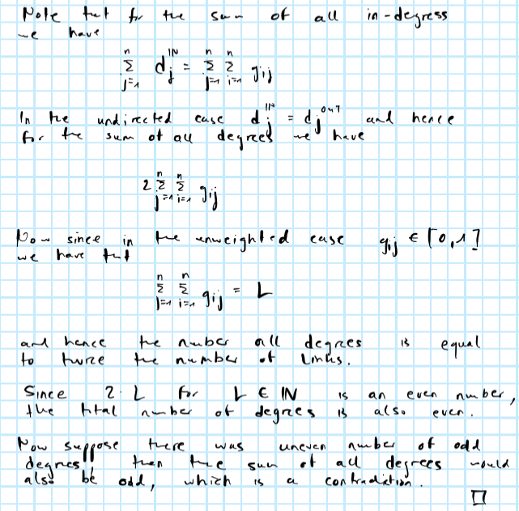

## b)

There are always at least two nodes with same degree.

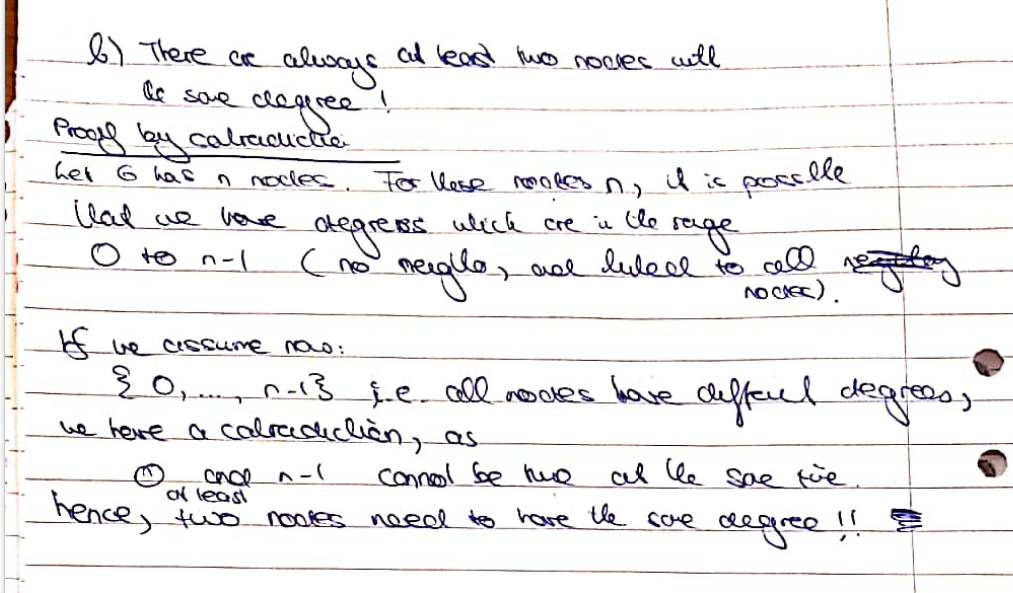

# Problem 2

Given the adjacency matrix $G$ of a directed and unweighted network, provide an interpretation for the entries in the matrices $GG^T$ and $G^TG$, where $G^T$ is the transpose of $G$. Make use of a small (not more than ten nodes) directed network to illustrate numerically the differences between both matrices.

Consider the following graph

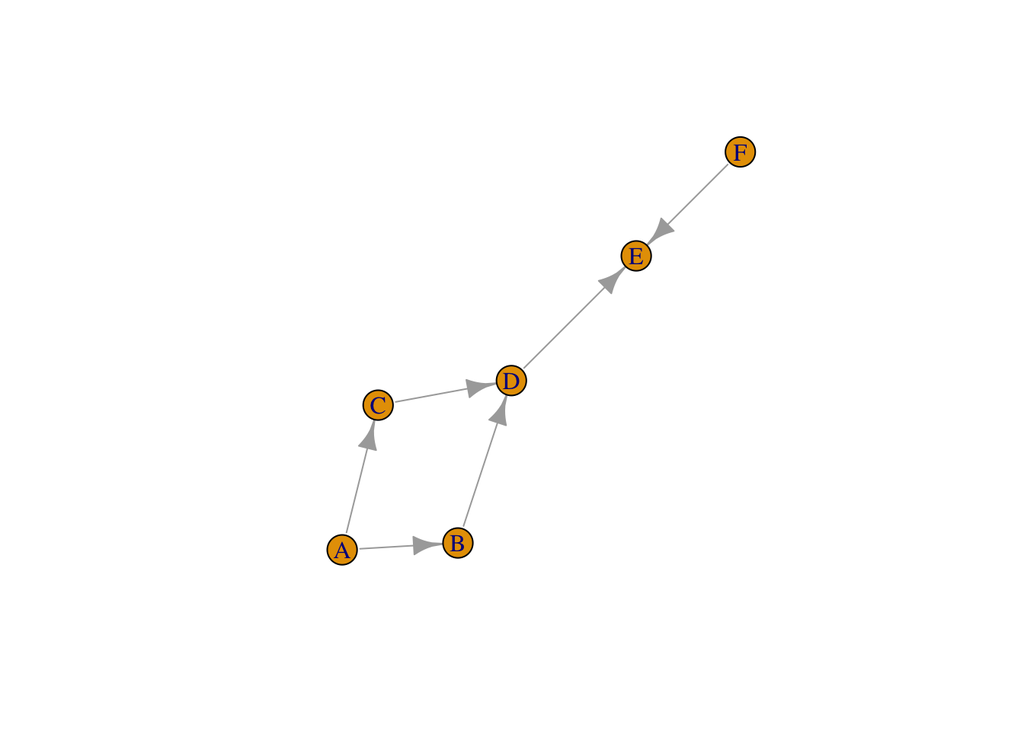

and its corresponding adjacency matrix:

$$\begin{equation}
\begin{aligned}
&& G&=\begin{bmatrix} 0 & 1 & 1 & 0 & 0 & 0 \\ 0 & 0 & 0 & 1 & 0 & 0 \\ 0 & 0 & 0 & 1 & 0 & 0 \\ 0 & 0 & 0 & 0 & 1 & 0 \\ 0 & 0 & 0 & 0 & 0 & 0 \\ 0 & 0 & 0 & 0 & 1 & 0 \\ \end{bmatrix}\\
\end{aligned}
\tag{1}
\end{equation}$$

Then we have for the two crossproducts we have

$$\begin{equation}
\begin{aligned}
&& GG^T&=\begin{bmatrix} 2 & 0 & 0 & 0 & 0 & 0 \\ 0 & 1 & 1 & 0 & 0 & 0 \\ 0 & 1 & 1 & 0 & 0 & 0 \\ 0 & 0 & 0 & 1 & 0 & 1 \\ 0 & 0 & 0 & 0 & 0 & 0 \\ 0 & 0 & 0 & 1 & 0 & 1 \\ \end{bmatrix} \\
\end{aligned}
\tag{2}
\end{equation}$$

and

$$\begin{equation}
\begin{aligned}
&& G^TG&=\begin{bmatrix} 0 & 0 & 0 & 0 & 0 & 0 \\ 0 & 1 & 1 & 0 & 0 & 0 \\ 0 & 1 & 1 & 0 & 0 & 0 \\ 0 & 0 & 0 & 2 & 0 & 0 \\ 0 & 0 & 0 & 0 & 2 & 0 \\ 0 & 0 & 0 & 0 & 0 & 0 \\ \end{bmatrix} \\
\end{aligned}
\tag{3}
\end{equation}$$

This example illustrates nicely how we can interpret elements in (2) and (3). With respect to (2), firstly note that the elements on the diagonal correspond to the out-degrees of nodes: for example, the out-degree of node $A$ is equal to 2, while the out-degree of $E$ is 0. Off-diagonal elements in (2) indicate the number of outgoing nodes that $j$ and $i$ share: for example, nodes $B$ and $C$ share 1 node. With respect to (3) the narrative is very similar, except that everything revolves around in-degrees: diagonal elements reveal the number in-degrees of nodes, while off-diagonal elements indicate how many ingoing nodes $j$ and $i$ share.

# Problem 3

Read the section on bipartite networks in Barabasi, chapter 2, and solve the two problems on bipartite networks at the end of the chapter.

## a)

Consider the bipartite network of Image 2.21

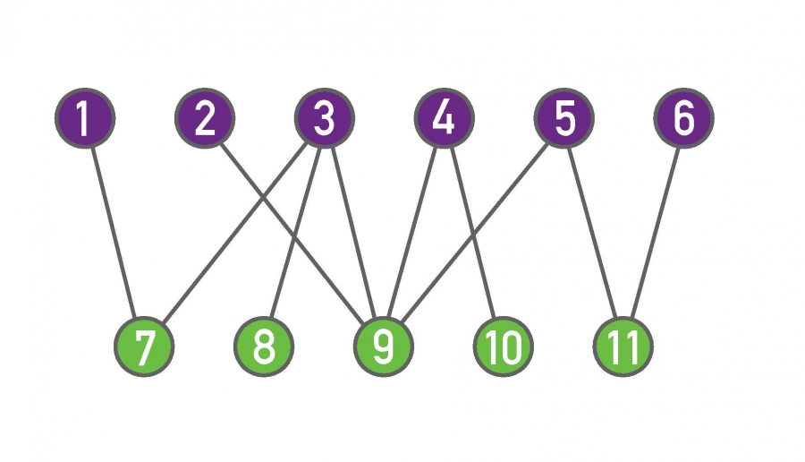

### (i)

Construct its adjacency matrix. Why is it a block-diagonal matrix?

The adjacency matrix

$$\begin{equation}
\begin{aligned}
&& G&=\begin{bmatrix} 0 & 0 & 0 & 0 & 0 & 0 & 1 & 0 & 0 & 0 & 0 \\ 0 & 0 & 0 & 0 & 0 & 0 & 0 & 0 & 1 & 0 & 0 \\ 0 & 0 & 0 & 0 & 0 & 0 & 1 & 1 & 1 & 0 & 0 \\ 0 & 0 & 0 & 0 & 0 & 0 & 0 & 0 & 1 & 1 & 0 \\ 0 & 0 & 0 & 0 & 0 & 0 & 0 & 0 & 1 & 0 & 1 \\ 0 & 0 & 0 & 0 & 0 & 0 & 0 & 0 & 0 & 0 & 1 \\ 1 & 0 & 1 & 0 & 0 & 0 & 0 & 0 & 0 & 0 & 0 \\ 0 & 0 & 1 & 0 & 0 & 0 & 0 & 0 & 0 & 0 & 0 \\ 0 & 1 & 1 & 1 & 1 & 0 & 0 & 0 & 0 & 0 & 0 \\ 0 & 0 & 0 & 1 & 0 & 0 & 0 & 0 & 0 & 0 & 0 \\ 0 & 0 & 0 & 0 & 1 & 1 & 0 & 0 & 0 & 0 & 0 \\ \end{bmatrix} \\
\end{aligned}
\tag{4}
\end{equation}$$

is block-diagonal, because it by construction its nodes can be divided into two disjoint sets $U=\{1,2,3,4,5,6\}$ and $V=\{7,8,9,10,11\}$. In other words, nodes in $U$ are connected only to nodes in $V$ and vice-versa.

### (ii)

Construct the adjacency matrix of its two projections, on the purple and on the green nodes, respectively.

```r
G_U <- crossprod(t(G[1:6,7:11]))
diag(G_U) <- 0
G_U_lat <- matrix2latex(G_U)
```

The adjacency matrix of the purple projection is

$$\begin{equation}
\begin{aligned}
&& G_U&=\begin{bmatrix} 0 & 0 & 1 & 0 & 0 & 0 \\ 0 & 0 & 1 & 1 & 1 & 0 \\ 1 & 1 & 0 & 1 & 1 & 0 \\ 0 & 1 & 1 & 0 & 1 & 0 \\ 0 & 1 & 1 & 1 & 0 & 1 \\ 0 & 0 & 0 & 0 & 1 & 0 \\ \end{bmatrix} \\
\end{aligned}
\tag{5}
\end{equation}$$

which can be computed as $\{G\}_{(1:6,7:11)}\{G\}_{(1:6,7:11)}^T$ and then setting diagonal elements to zero.

```r
G_V <- crossprod(t(G[7:11,1:6]))
diag(G_V) <- 0
G_V_lat <- matrix2latex(G_V)
```

$$\begin{equation}
\begin{aligned}
&& G_V&=\begin{bmatrix} 0 & 1 & 1 & 0 & 0 \\ 1 & 0 & 1 & 0 & 0 \\ 1 & 1 & 0 & 1 & 1 \\ 0 & 0 & 1 & 0 & 0 \\ 0 & 0 & 1 & 0 & 0 \\ \end{bmatrix} \\
\end{aligned}
\tag{6}
\end{equation}$$

which can be computed as $\{G\}_{(7:11,1:6)}\{G\}_{(7:11,1:6)}^T$ and then setting diagonal elements to zero.

### (iii)

Calculate the average degree of the purple nodes and the average degree of the green nodes in the bipartite network.

Average degrees can be computed as $\frac{1}{6}\{\mathbf{1}_d^T G \mathbf{1}_d\}_{(1:6,7:11)}$ and $\frac{1}{5}\{\mathbf{1}_d^T G \mathbf{1}_d\}_{(7:11,1:6)}$, respectively:

| Set | Avg. degree |
| --- | --- |
| U | 1.666667 |
| V | 2.000000 |

### (iv)

Calculate the average degree in each of the two network projections. Is it surprising that the values are different from those obtained in point (iii)?

Average degrees can be computed as $\frac{1}{d} ( \mathbf{1}_d^T G_S \mathbf{1}_d)$ where $S\in\{U,V\}$:

```r
avg_d_U <- as.numeric(rep(1,ncol(G_U)) %*% G_U %*% rep(1,ncol(G_U))/ncol(G_U))
avg_d_V <- as.numeric(rep(1,ncol(G_V)) %*% G_V %*% rep(1,ncol(G_V))/ncol(G_V))
```

This yields $\bar{d}_U=2.6666667$ and $\bar{d}_V=2$. It is not surprising that they differ. Consider this simple, but illustrative example of a bipartite network: let $U={A,B}$ and $V=[1,100]$ and suppose each node in $V$ is connected to $A$, with only node $1$ connected to $B$. Then clearly $A$’s degree within the whole network is 100 and $B$’s degree is one. Within the projection of $U$ both $A$ and $B$ have the same degree 1.

## b)

Consider a bipartite network with $N_1$ and $N_2$ nodes in the two sets.

### (i)

What is the maximum number of links $L_{max}$ the network can have?

Since nodes within the two disjoint sets cannot be connected to each other, but there can be arbitrarily many links between the two sets: $L\le N_1N_2$ and hence $L_{max}=N_1N_2$.

### (ii)

How many links cannot occur compared to a non-bipartite network of size $N = N_1 + N_2$?

For a non-bipartite network we have $\tilde{L}_{max}=\binom{N_1+N_2}{2}= \frac{(N_1+N_2)(N_1+N_2-1)}{2}$. By expanding the product, this can be rearranged as follows:

$$\begin{aligned}
&& \tilde{L}_{max}&=\frac{N_1(N_1-1)+N_1N_2+N_2(N_2-1)+N_2N_1}{2} \\
&& &= \frac{N_1(N_1-1)+N_2(N_2-1)}{2} + N_1N_2 \\
&& &= \binom{N_1}{2} + \binom{N_2}{2} + N_1N_2\\
&& \tilde{L}_{max}&= \binom{N_1}{2} + \binom{N_2}{2} + L_{max} \\
\end{aligned}$$
Hence, the number of links that cannot occure in a bipartite network compared to a non-bipartite network is simply equal to $\Delta=\binom{N_1}{2} + \binom{N_2}{2}$

### (iii)

If $N1<<N2$ , what can you say about the network density, that is the total number of links over the maximum number of links, $L_{max}$?

The smaller the ratio $\frac{N_1}{N_2}$ where $N_1<N2$ (or equivalently the smaller $\frac{N_2}{N_1}$ where $N_2<N_1$), the smaller $L_{max}$.

### (iv)

Find an expression connecting $N1$, $N2$ and the average degree for the two sets in the bipartite network, $〈k1〉$ and $〈k2〉$.

As per above, we can denote more generally

$$\begin{aligned}
&& 〈k1〉&=\frac{1}{N_1}\{\mathbf{1}_d^T G \mathbf{1}_d\}_{(1:N_1,(N_1+1):N)} \\
&& 〈k2〉&=\frac{1}{N_2}\{\mathbf{1}_d^T G \mathbf{1}_d\}_{( (N_1+1):N, 1:N_1)} \\
\end{aligned}$$

where $G$ is the adjacency matrix. Alternatively, we can use a notation in terms of sums:

$$\begin{aligned}
&& 〈k1〉&=\frac{1}{N_1}\sum_{i \in U} \sum_{j \in V} g_{ij} \\
&& 〈k2〉&=\frac{1}{N_2} \sum_{j \in V} \sum_{i \in U} g_{ji} \\
\end{aligned}$$

# Problem 4

Consider the star network, in which there are n nodes with node 1, the hub, connected to all other nodes, the spokes, and the spokes are only connected to the hub. There are no self-loops.

## a)

Without using matrices try to answer the following questions:

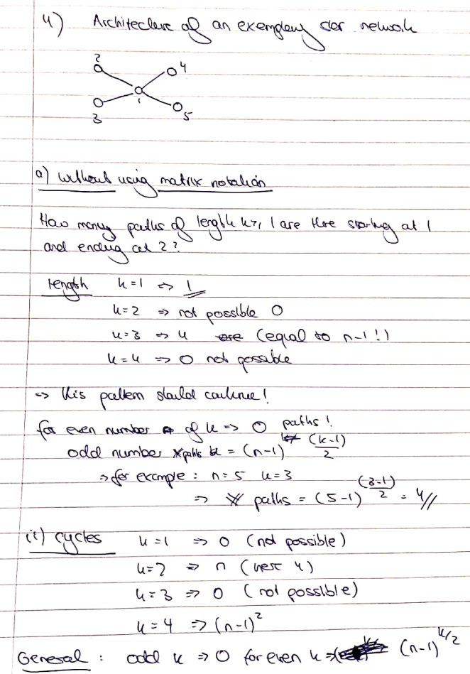

## b)

Write down the adjacency matrix G of this network.

The adjacency matrix is as follows (here $n=5$):

$$\begin{aligned}
&& G&=\begin{bmatrix} 0 & 1 & 1 & 1 & 1 \\ 1 & 0 & 0 & 0 & 0 \\ 1 & 0 & 0 & 0 & 0 \\ 1 & 0 & 0 & 0 & 0 \\ 1 & 0 & 0 & 0 & 0 \\ \end{bmatrix} \\
\end{aligned}$$

## c)

Below we show the first 5 powers of $G$:

$$\begin{aligned}
&& G^2&=\begin{bmatrix} 4 & 0 & 0 & 0 & 0 \\ 0 & 1 & 1 & 1 & 1 \\ 0 & 1 & 1 & 1 & 1 \\ 0 & 1 & 1 & 1 & 1 \\ 0 & 1 & 1 & 1 & 1 \\ \end{bmatrix}\\
&& G^3&=\begin{bmatrix} 0 & 4 & 4 & 4 & 4 \\ 4 & 0 & 0 & 0 & 0 \\ 4 & 0 & 0 & 0 & 0 \\ 4 & 0 & 0 & 0 & 0 \\ 4 & 0 & 0 & 0 & 0 \\ \end{bmatrix}\\
&& G^4&=\begin{bmatrix} 16 & 0 & 0 & 0 & 0 \\ 0 & 4 & 4 & 4 & 4 \\ 0 & 4 & 4 & 4 & 4 \\ 0 & 4 & 4 & 4 & 4 \\ 0 & 4 & 4 & 4 & 4 \\ \end{bmatrix}\\
&& G^5&=\begin{bmatrix} 0 & 16 & 16 & 16 & 16 \\ 16 & 0 & 0 & 0 & 0 \\ 16 & 0 & 0 & 0 & 0 \\ 16 & 0 & 0 & 0 & 0 \\ 16 & 0 & 0 & 0 & 0 \\ \end{bmatrix}\\
\end{aligned}$$

As a general rule, we have for even powers ($k\in[2,4,6,...]$)

$$\begin{aligned}
&& G^k&= \begin{pmatrix}
(n-1)^{( \frac{k}{2})} & 0 & ... & 0 \\
0 & (n-1)^{( \frac{k}{2}-1)} & ... & (n-1)^{( \frac{k}{2}-1)} \\
... & ... & ... & ... \\
0 & (n-1)^{( \frac{k}{2}-1)} & ... & (n-1)^{( \frac{k}{2}-1)}
\end{pmatrix}
\\
\end{aligned}$$

## d)

We could compute the centrality with respect to the number of paths of length $l\in[1,\ell]$, as we saw in class, for example up to $\ell=5$:

$$\begin{aligned}
&& \mathbf{c}&=\alpha \left( \mathbf{1} + \beta G \mathbf{1} + \beta^2 G^2 \mathbf{1} + ... + \beta^5 G^5 \mathbf{1} \right) \\
\end{aligned}$$

Letting $\alpha=2$ and $\beta=0.25$ we get

```r
deg <- alpha * (
  rep(1,d) +
    beta * G %*% rep(1,d)+
    beta^2 * G %^% 2 %*% rep(1,d) +
    beta^3 * G %^% 3 %*% rep(1,d) +
    beta^4 * G %^% 4 %*% rep(1,d) +
    beta^5 * G %^% 5 %*% rep(1,d)
)
kable(data.table(deg=deg, node=1:5), col.names = c("Degree", "Node"))
```

| Degree | Node |
| --- | --- |
| 5.25000 | 1 |
| 3.28125 | 2 |
| 3.28125 | 3 |
| 3.28125 | 4 |
| 3.28125 | 5 |

## e)

Now compute again the Katz-Bonacich centrality of each node by directly solving the linear system equations that characterizes it, and check that you obtain the same result as in the previous section.

We have simply have:

$$\begin{aligned}
&& \mathbf{c}&= \alpha \begin{pmatrix}
1 & -\beta \mathbf{1}^T_{(n-1)} \\
-\beta \mathbf{1}_{(n-1)} & \mathbf{I}_{(n-1)}
\end{pmatrix}^{-1} \mathbf{1}\\
\end{aligned}$$

For the same parameters as before we have

| Degree | Node |
| --- | --- |
| 5.333333 | 1 |
| 3.333333 | 2 |
| 3.333333 | 3 |
| 3.333333 | 4 |
| 3.333333 | 5 |

which is very similar. As $\ell \rightarrow \infty$ the solution in (d) converges to the solution here in (e).

# Problem 5

Consider a network with the following adjacency matrix

$$\begin{equation}
\begin{aligned}
&& G&=\begin{bmatrix} 0 & 0 & 0 & 1 & 0 & 0 & 1 & 0 \\ 0 & 0 & 1 & 0 & 1 & 1 & 0 & 0 \\ 0 & 1 & 0 & 0 & 0 & 0 & 0 & 0 \\ 1 & 0 & 0 & 0 & 0 & 0 & 1 & 1 \\ 0 & 1 & 0 & 0 & 0 & 1 & 0 & 0 \\ 0 & 1 & 0 & 0 & 1 & 0 & 0 & 0 \\ 1 & 0 & 0 & 1 & 0 & 0 & 0 & 1 \\ 0 & 0 & 0 & 1 & 0 & 0 & 1 & 0 \\ \end{bmatrix} \\
\end{aligned}
\tag{7}
\end{equation}$$

## a)

How many components there are in this network?

There are two components in the network:

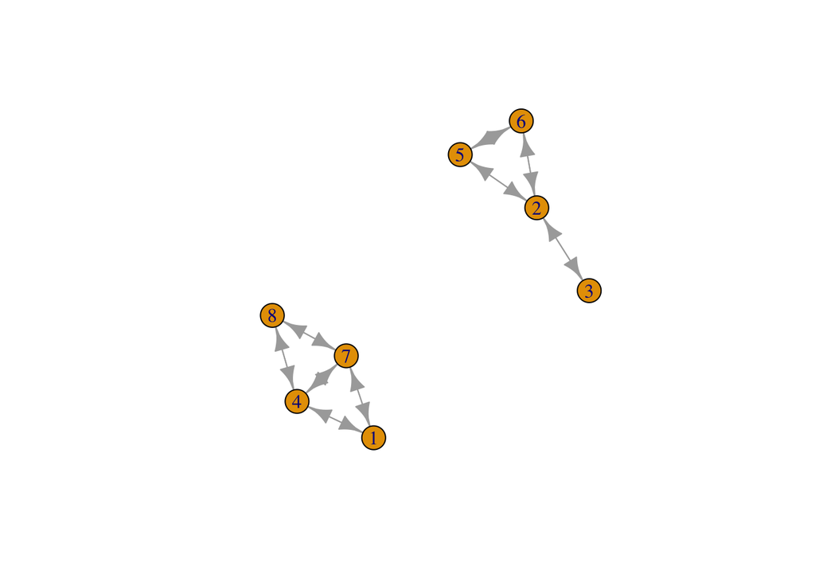

## b)

There are 0 paths of length 7 from node 1 to 5 (these nodes are in different components). There are 130 paths of length 7 from node 1 to 8. This values corresponds to the $ij$-th element of $G^{l=7}_{(1,8)}$.

## c)

Given parameters $α$ and $β$, compute the Katz-Bonacich centrality of each node.

We implement Katz-Bonacich as follows:

```r
katz_bonacich <- function(alpha, beta, G) {
  d <- nrow(G)
  qr.solve(diag(d) - beta * G, alpha * rep(1,d))
}
```

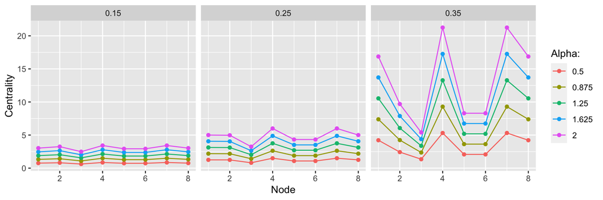

Figure 1: Katz-Bonacich centrality for different parameter choices.

## d)

Order nodes according to Katz-Bonacich centrality for the particular case in which $α=2$ and $β=0.25$. Would it change anything in this order if we change $α=2$ for some other strictly positive number?

In this case the order is as follows:

| Centrality | Node |
| --- | --- |
| 6.00 | 7 |
| 6.00 | 4 |
| 5.00 | 1 |
| 5.00 | 8 |
| 4.97 | 2 |
| 4.32 | 5 |
| 4.32 | 6 |
| 3.24 | 3 |

As evident from Figure 1 above, the effect of $\alpha$ is purely scaling, so nothing would change with respect to the relative ordering.

## e)

Compute the eigenvector centrality of each node. You can use a computer to make computations but you cannot directly use some network analysis software with a build function to compute this directly. Explain the steps you follow.

Given $G$ is a positive matrix, it suffices to find its leading eigenvalue $\lambda$. The by the Perron-Frobenius (PF) theorem there exists a positive eigenvector $v$. Hence we simply proceed as follows:

1. Eigen-decompose $G$.
2. Find the eigenvector $v$ corresponding to the leading eigenvalue $\lambda$. By the PF theorem the there exists a an eigenvector $\tilde{v}$ that only has non-negative entries. Consequently, $v$ can be either all positive or all negative and hence we simply take element-wise absolute values to ensure the former. 3. Finnaly we scale $\tilde{v}$ such that its largest element is equal to 1.

In R we implement this as follows:

```r
centrality_eigen <- function(G, scale=TRUE) {
  list2env(eigen(G), envir = environment())
  v <- abs(vectors[,1]) # by Perron-Forbenius Theorem
  if (scale) {
    v <- v/max(v)
  }
  return(v)
}
```

| Centrality | Node |
| --- | --- |
| 1.00 | 4 |
| 1.00 | 7 |
| 0.78 | 1 |
| 0.78 | 8 |
| 0.00 | 2 |
| 0.00 | 3 |
| 0.00 | 5 |
| 0.00 | 6 |

# Problem 6

## a)

Consider the following network, that we are going to call a circle: node 1 is connected to node n and node 2, node 2 is connected to node 1 and node 3, node 3 is connected to node 2 and node 4,…, node n is connected to node n-1 and node 1. What is the diameter of that network? Is that network bipartite?

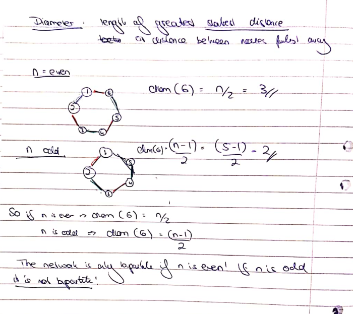

## b)

Find a network with largest possible diameter within the set of networks that have n nodes and just one single component.

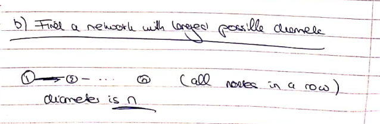

## c)

Find a network with smallest possible diameter within the set of networks that have n nodes and just one single component.

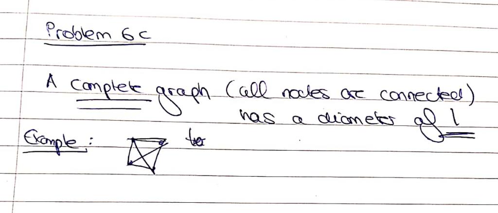

## d)

Find an undirected network with one single component in which the diameter is 4 times larger than the average distance.

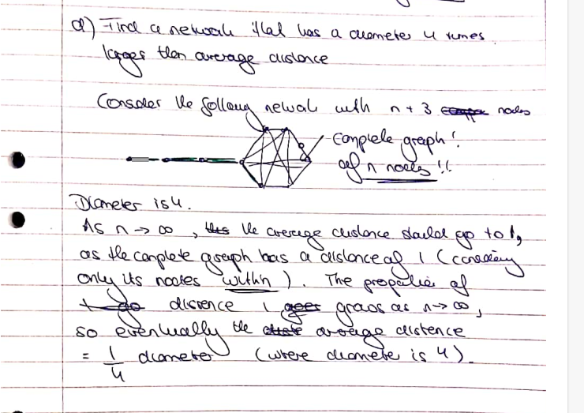

# Problem 7

Find the dataset about jazz musicians, from the paper P.Gleiser and L. Danon , Adv. Complex Syst.6, 565 (2003). Using some software for network analysis:

## a)

Compute the degree centrality of each node.

Degree centrality can be implemented in R as follows:

```r
centrality_degree <- function(G) {
  G <- as.matrix(G)
  c <- unlist(G %*% rep(1,nrow(G)) + t(G) %*% rep(1,nrow(G)))
  return(c)
}
```

Below we compute the degree centralities of the nodes and store them in a data frame.

```r
centr <- centrality_degree(G)
bands[,centr_degree:=centr]
```

## b)

Compute the eigenvector centrality of each node.

Below we compute the eigenvector centralities of the nodes and store them in the same data frame.

```r
centr <- centrality_eigen(G)
bands[,centr_eigen:=centr]
```

## c)

Compare the top 10 nodes according to the previous two centrality measures.

The table below shows the top 10 nodes for the two different centrality measures. While the ranking is not exactly the same, the two measures share 8 common nodes in the top 10.

| Rank | Degree | Eigen |
| --- | --- | --- |
| 1 | 136 | 60 |
| 2 | 60 | 132 |
| 3 | 132 | 136 |
| 4 | 168 | 168 |
| 5 | 70 | 108 |
| 6 | 99 | 99 |
| 7 | 108 | 131 |
| 8 | 83 | 70 |
| 9 | 158 | 83 |
| 10 | 7 | 194 |

## d)

Compute the individual clustering coefficients of each node, and the average clustering coefficient. Compare this average clustering to the ratio $L/ \binom{N}{2}$ of that network.

Clustering coefficients are computed as follows:

$$\begin{equation}
\begin{aligned}
&& C_i&= \frac{1}{d_i(d_i-1)} \sum_{j,k} G_{ij} G_{jk} G_{ki}\\
\end{aligned}
\tag{8}
\end{equation}$$

In R this can be implemented as follows:

```r
cluster_coeff <- function(G, type="individual") {
  G <- as.matrix(G)
  deg <- G %*% rep(1,ncol(G))
  norm <- (1/(deg*(deg-1)))
  norm[is.infinite(norm)] <- 0
  clust <- as.numeric(norm * (G * crossprod(G)) %*% rep(1,ncol(G)))
  if (type=="average") {
    clust <- mean(clust_coeffs)
  }
  return(clust)
}
```

```r
clust_coeff <- cluster_coeff(G)
clust_avg <- mean(clust_coeff)
n <- nrow(G)
L <- sum(G %*% rep(1, nrow(G)))/2
ratio <- L/choose(n,2)
```

The average clustering coefficient is 0.6174507, which compares to $L/\binom{N}{2}=0.1405938$.